# Just enough machine learning to be dangerous

Pierre Roudier

2017-09-21

# What is machine learning?

**Machine learning** is an application of artificial intelligence that provides systems the ability to automatically learn and improve from experience without being explicitly programmed (after Arthur Samuel, 1959).

In this course, we will essentially talk about **supervised** machine learning — where the learning algorithm produces an inferred function to make predictions about the output values from rules derived on a learning set.

Modern machine learning algorithms are developing very quickly. They tend to try and leverage computing power. Another tendency is for these methods to focus on the **predictive power** rather than the **interpretability** of the model.

# Classification and regression

The problems solved by supervised machine learning can be:

- **Classification**: assign a *label* (or class) to an observation. Eg spam filtering (“spam” vs. “not spam”).
- **Regression**: asign a continuous *value* to an observation. Eg predict daily email volume.

Typically, for digital soil mapping, predicting soil **classes** is a classification problem, while predicting soil **attributes** is a regression problem.

# Assessing of the performance of the model

There are different reasons why we would like to assess the predictive performance of a model:

- Estimate the **predictive performance** of the model on unseen data,
- Tune the model and **select the best parameters**,
- **Compare** different machine learning algorithms.

There are two components to model performance:

- the prediction **variance** (variability of the model’s predictions if we repeat the learning process)
- the prediction **bias** (systematic difference between the model’s predictions and the true values)

We want to good trade-off between variance and bias.

[figure not shown]

## Calibration vs. validation

Obviously, the dataset used during the learning stage of machine learning is **very important**.

We separate:

- The **training set** (or calibration set), on which the machine learning method is “trained”,
- The **test set** (or validation set), on which the performance of the machine learning method is assessed.

The validation or test step is very important, and gives an idea of the accuracy of our classification or regression method.

- **External validation**: gold standard: we go back in the field and bring back an independent dataset
- **Internal validation**: we set aside a given percentage of our training data for testing purposes
- **Resampling strategies**: we simulate internal validation, useful for parameter tuning and small datasets

The golden rule: your validation set should not be used to “tune” your model!

## Internal (or holdout) validation

The internal (or holdout) validation is the easiest validation process to implement:

1. We divide randomly our entire dataset into a training and a test set (typically 2/3 – 1/3).

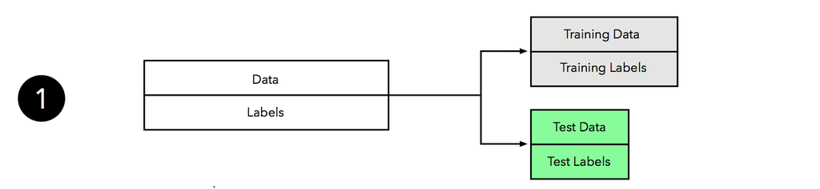

2. We try different parameter values for a given learning algorithm on the training set.

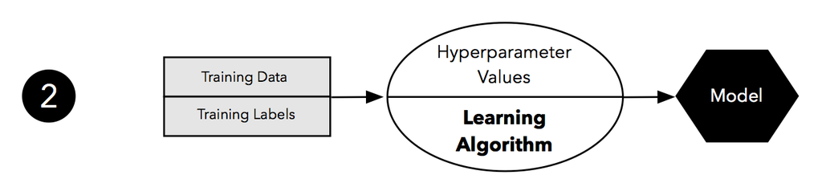

3. The test set comesin once we want to assess how “good” a model is.

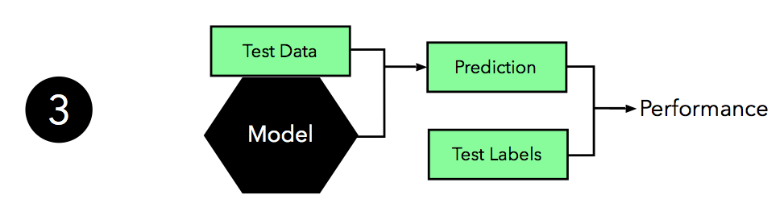

## The dangers of overfitting

> With four parameters I can fit an elephant and with five I can make him wiggle his trunk. —John von Neumann

Over-fitting occurs when a classification or regression model learns not only actual pattern in the data, but also the noise:

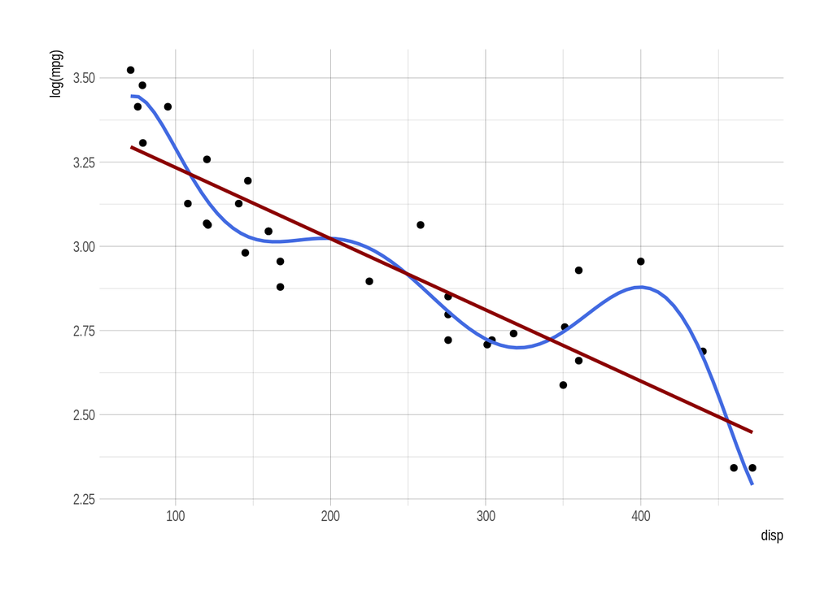

| model | r.squared | adj.r.squared |
| --- | --- | --- |
| red | 0.78 | 0.77 |
| blue | 0.91 | 0.88 |

```
True Prediction Error = Training Error + Training Optimism
```

where *Training Optimism* measure how much worse the model is on new, unseen data.

It turns out that *Model Complexity* influences *Training Optimism*:

```
True Prediction Error = Training Error + f(Model Complexity)
```


# Resampling strategies

Using a simple holdout makes it tricky to tune the model parameters. A solution is to “simulate” the availability of held out data during that tuning process.

The most common way to do this is to use **k-fold cross-validation** (typically k = 5 or k = 10):

[figure not shown]

This process can be repeated N times to take into account the random affectation of samples to folds. We talk about **repeated k-fold cross-validation**.

**Bootstrapping** is another popular option:

[figure not shown]

# For more information

- A great suite of blog posts by Sebastian Raschka:
  - [Part I](https://sebastianraschka.com/blog/2016/model-evaluation-selection-part1.html)
  - [Part II](https://sebastianraschka.com/blog/2016/model-evaluation-selection-part2.html)
  - [Part III](https://sebastianraschka.com/blog/2016/model-evaluation-selection-part3.html)
- [Comparison of bootstraping and cross-validation](http://appliedpredictivemodeling.com/blog/2014/11/27/08ks7leh0zof45zpf5vqe56d1sahb0) by Max Kuhn